# Simulating Visium HD data with geo.spatialtrans

Usage guide for Step 2: from simulated cells to 2 µm and 8 µm counts

Published

November 12, 2026

This guide shows how to turn a simulated cell layer (Step 1) into Visium HD data (Step 2): gene counts on the 2 µm grid, their sums on 8 µm bins, and the ground truth that a method can be scored against. Every code chunk below runs when the guide is rendered, on the lab server, with the project library; the numbers in the outputs come from that run.

The entry point is `simulate_visium_hd_pieces()` (decision DEC-079). It splits the area into square pieces, simulates each cell once in the piece that holds its centre, and passes the transcripts that land in another piece to that piece. All random draws are tied to fixed 56 µm tiles, so **the result does not depend on the piece size or on the number of processes** (DEC-074). `simulate_visium_hd()`, written earlier (step S2.5), stays in the code as the reference engine of the test batteries: with the same seed it gives another realisation of the same model, not the same counts. The two engines differ in three declared details: the entry point cuts the stripe factors at a fixed ceiling (see Technical layers), computes the distance to the tissue edge on windows around each piece, and reflects the second tail on the box given by `frame`.

## What the simulator does

The model is described in the Step 2 design document, `docs/superpowers/specs/2026-11-03-step2-visium-grid-design.md` (version 0.6); the steps that built and checked each part are in `docs/steps/` (S2.0 to S2.8). In short, for each cell of the cell layer (the function names are those of the step functions; the entry point uses the same arithmetic, see Lower-level functions):

1. **Grid and geometric truth** (`build_hd_grid()`): a 2 µm grid around the tissue with a 280 µm margin of glass; for every pair (bin, cell) the area of the bin covered by the cell territory and by its nucleus.
2. **Transcripts per cell** (`simulate_cell_profiles()`): a subtype and a total number of transcripts for each cell, and gene counts drawn from the expression profiles of its tissue (`load_cell_profiles()`), scaled by a depth factor (`visium_hd_depth_factor()`).
3. **Position and movement** (`place_and_move_transcripts()`): each transcript is born in the nucleus or in the cytoplasm, with a fine random field at 1-2 µm, and then moves. The first displacement is a mixture: for a small share of transcripts (`w`, 4 to 11 % by tissue) an exponential tail of tens of µm (`ell`, 25 to 42 µm); otherwise a narrow Gaussian blur (`sigma_in`), replaced near the tissue edge by a wider one (`sigma_e`, with probability decaying over the depth `D`). Then a long second tail (`w2`, 2 to 8 %; `ell2`, 113 to 1826 µm) carries transcripts onto the glass. The first displacement and the fine field are in `transcript_params()`.
4. **Capture and binning** (`capture_and_bin()`): row and column stripes of the capture efficiency (`simulate_stripes()`), thinning to the expected capture, a background on every bin, and the sum to 8 µm bins (`sum_to_8um()`). The capture parameters of each tissue, including the background `b` and the second tail, fitted together (DEC-053), are in `capture_params()`.

Transcripts are generated in excess and thinned by the stripe factor; the excess (the overgeneration) has a fixed ceiling for each tissue (`stripe_ceiling()`, DEC-075).

## Setup

From the repository root, after `Rscript --vanilla tools/restore_library.R` (see `README.md`). The expression profiles are read from the server data volume (`/mnt/micron/geo_spatialtrans/S2.2/profiles`, 15 MB); another folder can be set with `options(geo.spatialtrans.profiles_dir = ...)`.

```r
.libPaths("renv/library/linux-ubuntu-noble/R-4.6/x86_64-pc-linux-gnu")
suppressPackageStartupMessages({ library(sf); library(geos); library(Matrix) })
for (f in sort(list.files("R", pattern = "^(04b|05b).*\\.R$", full.names = TRUE))) source(f)
```

Messages and error texts of the code are in Italian.

## A first simulation

A disc of mouse small intestine, 200 µm in radius, drawn on 2 µm pixels. `place_cells()` builds the cell layer (Step 1, see `README.md`); the preset decides the tissue, and `visium_hd_archetype()` maps it to the tissue code of the Step 2 parameters (A1 is the intestine, A2 the colorectal cancer, A3 its stroma, A4 the lymph node, A5 the mouse brain, A6 the heart).

```r
px <- 2
xy <- expand.grid(x = 1:240, y = 1:240)
disc <- (xy$x * px - 240)^2 + (xy$y * px - 240)^2 <= 200^2
clust <- data.frame(xy[disc, ], intensity_cluster = 1L)
cl <- place_cells(clust, tissue_preset = "epithelial", pixel_size_um = px, random_seed = 42)
```

```
[place_cells] epithelial: 1 regioni, 1561 cellule, scala 2 um/px (user), controlli 0 ERROR / 0 WARN, 2.2 s
```

```r
visium_hd_archetype(cl)
```

```
[1] "A1"
```

The simulation needs the cell layer and a seed. On a small area the fastest choice is a single piece, `piece_um = Inf` (see Piece size, time and memory).

```r
hd <- simulate_visium_hd_pieces(cl, seed = 1, piece_um = Inf)
dim(hd$counts_2um)     # genes x 2 um bins (tissue, lumens and glass)
```

```
[1]  19059 234256
```

```r
dim(hd$counts_8um)     # genes x 8 um bins
```

```
[1] 19059 14641
```

```r
unlist(hd$metadata$checks)
```

```
        cells_once          bins_once  conservation_cell conservation_total
              TRUE               TRUE               TRUE               TRUE
     sent_received          umi_total        genes_cells              no_na
              TRUE               TRUE               TRUE               TRUE
           sum_8um
              TRUE
```

```r
hd$metadata[c("archetype", "n_cells", "overgeneration", "n_generated", "n_captured", "n_background", "package_version")]
```

```
$archetype
[1] "A1"

$n_cells
[1] 1561

$overgeneration
[1] 4.134403

$n_generated
[1] 4225356

$n_captured
[1] 982427

$n_background
[1] 0

$package_version
[1] "geo.spatialtrans 0.2.0"
```

The internal checks (`metadata$checks`) confirm that every cell and every bin was simulated once, that transcripts are conserved through generation, loss, thinning and capture, and that the 8 µm counts are the sums of the 2 µm counts.

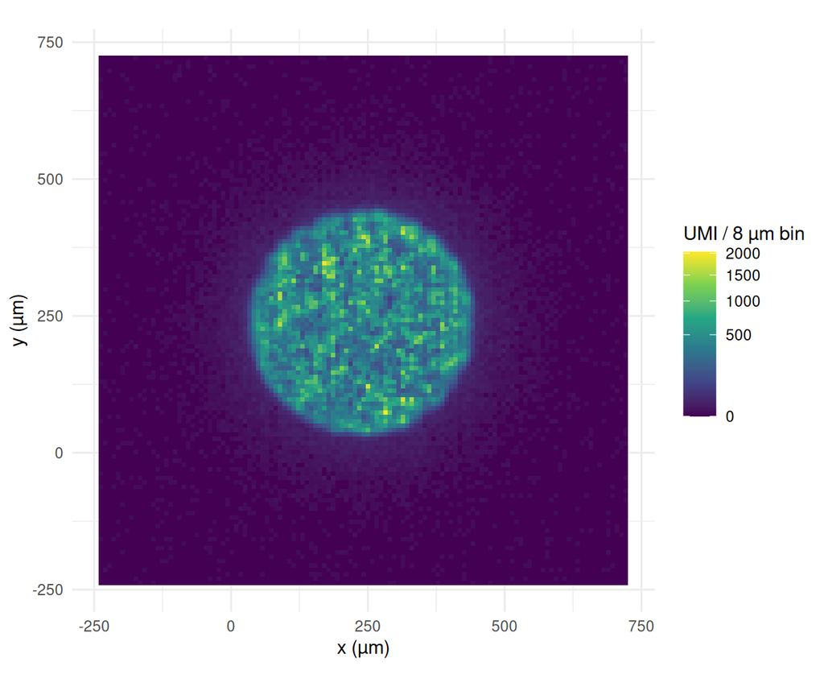

Figure 1: UMI per 8 µm bin of the simulated disc of intestine (seed 1). The square is the whole simulated grid, with 280 µm of glass around the tissue.

```r
library(ggplot2)
b8 <- hd$bins_8um
b8$umi <- Matrix::colSums(hd$counts_8um)
ggplot(b8, aes(x, y, fill = umi)) + geom_raster() + coord_equal() +
  scale_fill_viridis_c(trans = "sqrt", name = "UMI / 8 µm bin") +
  labs(x = "x (µm)", y = "y (µm)") + theme_minimal(base_size = 10)
```

## What comes out

With `assemble = "full"` (the default) the result is a list with the same structure as `simulate_visium_hd()`:

| element | content |
| --- | --- |
| `counts_2um` | sparse matrix genes × 2 µm bins, all bins of the grid |
| `counts_8um` | sparse matrix genes × 8 µm bins (sums of 4 × 4 bins of 2 µm) |
| `bins` | one row per 2 µm bin: grid row and column, centre (µm), 8 µm bin, tissue area and fraction, `in_tissue` (fraction ≥ 0.5), stripe factor used (`c`) and raw (`c_raw`) |
| `bins_8um` | one row per 8 µm bin: centre, tissue area, `n_in_tissue` (its 2 µm bins in the tissue, out of 16), `in_tissue` (at least one) |
| `truth$overlap`, `truth$overlap_8um` | for every pair (bin, cell): area and fraction of the bin covered by the territory and by the nucleus |
| `truth$origin`, `truth$origin_8um` | for every pair (bin, cell): captured transcripts of that cell in that bin, and how many were born in the nucleus |
| `truth$background`, `truth$background_8um` | background UMI per bin (not from any cell) |
| `truth$arrived_2um` | transcripts that arrived in each 2 µm bin before capture |
| `truth$cell_counts` | genes × cells matrix of the transcripts generated for each cell (the true profiles; returned only with `assemble = "full"` and `keep_profiles = TRUE`, the default) |
| `truth$cells`, `truth$genes` | per cell and per gene: generated, lost, thinned and captured transcripts; cell type and subtype |
| `truth$layers` | the technical layers actually used: stripe factors and their ceiling, background, displacement parameters, fine field, depth |
| `metadata` | seeds, pieces, grid, ceiling, checks, time and memory per stage and piece, version and fingerprints of the code and of the profiles |

```r
names(hd$truth)
```

```
 [1] "overlap"        "overlap_8um"    "origin"         "origin_8um"
 [5] "background"     "background_8um" "arrived_2um"    "cell_counts"
 [9] "cells"          "genes"          "layers"
```

```r
head(hd$truth$origin)
```

```
  bin_id cell_id n n_born_nucleus
1    536    1425 1              1
2    752     459 1              0
3    793     498 1              1
4   1237     571 1              0
5   1310     785 1              0
6   1492     108 1              0
```

```r
head(hd$truth$cells[, c("cell_id", "cell_type", "subtype", "n_transcripts_generated", "n_captured")])
```

```
  cell_id                 cell_type                      subtype
1       1               immunitario                immunitario|3
2       2                epiteliale                epiteliale|13
3       3 stromale e muscolo liscio stromale e muscolo liscio|14
4       4               immunitario               immunitario|10
5       5 stromale e muscolo liscio stromale e muscolo liscio|14
6       6                epiteliale                epiteliale|13
  n_transcripts_generated n_captured
1                    1373        290
2                    6793       1505
3                     703        183
4                    1013        213
5                    2414        535
6                    3524        847
```

## Ground truth for scoring methods

The truth tables are what a method is scored against. Two examples. **Bin-to-cell assignment**: the share of the cell-derived UMI of a 2 µm bin that comes from the cell whose territory covers most of the bin (1 would mean no transcript moved across territories).

```r
ov <- hd$truth$overlap
top <- ov[order(ov$bin_id, -ov$frac_territory), ]
top <- top[!duplicated(top$bin_id), c("bin_id", "cell_id")]
og <- hd$truth$origin
tot <- tapply(og$n, og$bin_id, sum)
own <- merge(og, top, by = c("bin_id", "cell_id"))
own_n <- tapply(own$n, own$bin_id, sum)
in_t <- hd$bins$bin_id[hd$bins$in_tissue]
share <- own_n[as.character(in_t)] / tot[as.character(in_t)]
summary(as.numeric(share[!is.na(share)]))
```

```
   Min. 1st Qu.  Median    Mean 3rd Qu.    Max.
0.01075 0.40000 0.63636 0.60252 0.82143 1.00000
```

**Cell-level truth**: `truth$cell_counts` holds the transcripts generated for each cell before movement and capture; together with `truth$origin` it gives the expected recovery of a segmentation-based method, cell by cell.

```r
cc <- hd$truth$cell_counts
dim(cc)
```

```
[1] 19059  1561
```

```r
all.equal(as.numeric(Matrix::colSums(cc)), hd$truth$cells$n_transcripts_generated)
```

```
[1] TRUE
```

The background is kept apart from the cells (`truth$background`): it is not in `truth$origin`.

## Same seed, same data, whatever the pieces

The same seed gives the same counts with any piece size (a multiple of 56 µm, or `Inf`) and any number of processes (`workers`, one child process per piece and stage).

```r
hd_pieces <- simulate_visium_hd_pieces(cl, seed = 1, piece_um = 112, workers = 2)
hd_pieces$metadata$n_pieces
```

```
[1] 81
```

```r
c(counts_2um = identical(hd$counts_2um, hd_pieces$counts_2um),
  counts_8um = identical(hd$counts_8um, hd_pieces$counts_8um),
  origin = identical(hd$truth$origin, hd_pieces$truth$origin),
  background = identical(hd$truth$background, hd_pieces$truth$background))
```

```
counts_2um counts_8um     origin background
      TRUE       TRUE       TRUE       TRUE
```

## Piece size, time and memory

The default, `piece_um = 504`, was chosen so that one piece stays within the 8 GB budget of the design document on whole capture areas: with 1008 µm a piece of the colorectal cancer and of the brain went above it (second table below; DEC-076). On small areas a single piece is faster. The table below is read from the measurements of step S2.8 (`results/S2.8/S2.8_summary.csv`): areas of 1 mm² of the six reference tissues, 3 seeds, one process each, default layers, `frame_open = TRUE`; `simulate_visium_hd()` ran with blocks of 4 million transcripts (`chunk_transcripts = 4e6`, its default is 2e6).

```r
s28 <- read.csv("results/S2.8/S2.8_summary.csv")
tissue <- c(A1 = "intestine", A2 = "colorectal cancer", A3 = "cancer stroma", A4 = "lymph node", A5 = "mouse brain", A6 = "heart")
conf <- c(einf = "piece_um = Inf", e1008 = "piece_um = 1008", e504 = "piece_um = 504 (default)", ref = "simulate_visium_hd()")
s28 <- s28[s28$conf %in% names(conf), ]
tab <- data.frame(tissue = tissue[s28$A], configuration = conf[s28$conf],
                  time_s = round(s28$time_mean), peak_GB = round(s28$peak_max, 1))
tab <- tab[order(match(tab$tissue, tissue), match(tab$configuration, conf)), ]
knitr::kable(tab, row.names = FALSE, col.names = c("tissue", "configuration", "time (s, mean of 3 seeds)", "peak memory (GB, max of 3 seeds)"))
```

| tissue | configuration | time (s, mean of 3 seeds) | peak memory (GB, max of 3 seeds) |
| --- | --- | --- | --- |
| intestine | piece_um = Inf | 180 | 4.6 |
| intestine | piece_um = 1008 | 211 | 3.7 |
| intestine | piece_um = 504 (default) | 217 | 2.6 |
| intestine | simulate_visium_hd() | 161 | 5.8 |
| colorectal cancer | piece_um = Inf | 218 | 6.2 |
| colorectal cancer | piece_um = 1008 | 259 | 4.7 |
| colorectal cancer | piece_um = 504 (default) | 270 | 3.2 |
| colorectal cancer | simulate_visium_hd() | 212 | 7.4 |
| cancer stroma | piece_um = Inf | 132 | 3.5 |
| cancer stroma | piece_um = 1008 | 154 | 2.8 |
| cancer stroma | piece_um = 504 (default) | 158 | 2.1 |
| cancer stroma | simulate_visium_hd() | 124 | 5.3 |
| lymph node | piece_um = Inf | 190 | 3.3 |
| lymph node | piece_um = 1008 | 206 | 2.3 |
| lymph node | piece_um = 504 (default) | 206 | 1.8 |
| lymph node | simulate_visium_hd() | 173 | 3.4 |
| mouse brain | piece_um = Inf | 180 | 4.8 |
| mouse brain | piece_um = 1008 | 221 | 4.8 |
| mouse brain | piece_um = 504 (default) | 220 | 2.7 |
| mouse brain | simulate_visium_hd() | 146 | 5.9 |
| heart | piece_um = Inf | 76 | 1.7 |
| heart | piece_um = 1008 | 81 | 1.5 |
| heart | piece_um = 504 (default) | 85 | 1.3 |
| heart | simulate_visium_hd() | 79 | 4.9 |

Whole capture areas need pieces. In step S2.7 five whole sections were simulated with 8 processes and `assemble = "light"` (the table is `results/S2.7/S2.7_P3_P4.csv`): the peak of one piece and the peak of the main process, which stitches the pieces together, are different budgets.

```r
s27 <- read.csv("results/S2.7/S2.7_P3_P4.csv")
s27$tissue <- tissue[sub("^sec_(A[0-9])_.*$", "\\1", s27$section)]
knitr::kable(data.frame(tissue = s27$tissue, piece_um = s27$piece_um, pieces = s27$n_pieces, tissue_mm2 = round(s27$tissue_mm2, 1),
                        piece_peak_GB = round(s27$piece_peak_gb, 1), main_peak_GB = round(s27$main_peak_gb, 1),
                        process_s_per_mm2 = round(s27$s_per_mm2_tissue), wall_min = round(s27$wall_s / 60)),
             col.names = c("tissue", "piece (µm)", "pieces", "tissue (mm²)", "peak of one piece (GB)", "peak of the main process (GB)",
                           "process time per mm² of tissue (s)", "wall time (min)"))
```

| tissue | piece (µm) | pieces | tissue (mm²) | peak of one piece (GB) | peak of the main process (GB) | process time per mm² of tissue (s) | wall time (min) |
| --- | --- | --- | --- | --- | --- | --- | --- |
| intestine | 1008 | 64 | 22.5 | 6.3 | 19.3 | 331 | 19 |
| colorectal cancer | 1008 | 64 | 33.1 | 12.5 | 33.7 | 388 | 32 |
| lymph node | 1008 | 64 | 22.5 | 4.1 | 10.1 | 233 | 13 |
| mouse brain | 1008 | 64 | 25.6 | 9.6 | 30.6 | 263 | 17 |
| heart | 1008 | 64 | 42.6 | 2.0 | 6.6 | 72 | 7 |
| colorectal cancer | 504 | 225 | 33.1 | 3.8 | 39.8 | 446 | 34 |
| mouse brain | 504 | 225 | 25.6 | 3.4 | 29.3 | 335 | 21 |

In practice:

- **areas up to about 1 mm²**: `piece_um = Inf`;
- **whole capture areas**: the default 504 µm, `assemble = "light"`, several `workers`, and a machine with room for the main process. The light output holds `umi_2um` (UMI per 2 µm bin), `counts_8um`, `bins`, `bins_8um`, `truth$cells`, `truth$genes`, `truth$background` and `truth$layers`; it has no `counts_2um`, `truth$overlap`, `truth$origin`, `truth$arrived_2um` or `truth$cell_counts`;
- `cell_layer` can be the path of an RDS file instead of the object: the file is read, split into pieces and freed, so the child processes do not carry the whole layer.

Choosing the piece size automatically is planned with the optimisation of the cell layer (backlog item BL-252). On whole sections the process time per mm² of tissue is above the 300 s budget of the design document in the colorectal cancer (with pieces of 1008 and of 504 µm), in the intestine (1008 µm; not run with 504 µm) and in the mouse brain with the default 504 µm (table above). The first two are a declared limit (DEC-077), written on the 1008 µm runs.

## Technical layers

`layers` switches the four technical layers: `stripes` (row and column capture factors), `background`, `field` (fine variability at 1-2 µm) and `second_tail` (the long movement that reaches the glass). All are on by default. A method that corrects one layer should be tested with that layer on, and compared with the same seed and the layer off.

```r
hd_flat <- simulate_visium_hd_pieces(cl, seed = 1, piece_um = Inf, layers = list(stripes = FALSE, background = FALSE))
# variability between grid columns of the mean UMI per tissue bin: the stripes add it
col_cv <- function(h) { u <- Matrix::colSums(h$counts_2um); k <- h$bins$in_tissue
  m <- tapply(u[k], h$bins$j[k], mean); sd(m) / mean(m) }
c(with_stripes = col_cv(hd), without_stripes = col_cv(hd_flat))
```

```
   with_stripes without_stripes
      0.3703661       0.1788832
```

```r
range(hd$bins$c)                 # stripe factor used on the 2 um bins
```

```
[1] 0.2419874 4.1344032
```

```r
range(hd_flat$bins$c)
```

```
[1] 1 1
```

How stripes and background work together:

- transcripts are generated with an overgeneration M* (`metadata$overgeneration` = `truth$layers$stripes$M`) and each one is kept with probability `c / M*` in the bin where it arrives, where `c` is the stripe factor of the bin;
- factors above the ceiling M* are cut to M*: `bins$c` is the factor used, `bins$c_raw` the raw one, and `metadata$truncated_share` the share of the expected captured transcripts removed by the cut. `ceiling_q` is the probability that a raw factor exceeds the ceiling (default 1e-5, DEC-075); `stripe_ceiling()` computes M* from `capture_params()`;
- the background of a bin is Poisson with mean `b c`, with the same cut factor `c` as the capture; `b` comes from `capture_params()` and is zero in some tissues (printed below).

```r
c(M_star = hd$metadata$overgeneration, M_raw = hd$truth$layers$stripes$M_raw,
  bins_over_ceiling = hd$metadata$n_bins_over_ceiling, truncated_share = hd$metadata$truncated_share)
```

```
           M_star             M_raw bins_over_ceiling   truncated_share
         4.134403          4.534231          2.000000          0.000000
```

```r
stripe_ceiling(capture_params("A1"))
```

```
[1] 4.134403
```

```r
sapply(c(A1 = "A1", A2 = "A2", A3 = "A3", A4 = "A4", A5 = "A5", A6 = "A6"), function(a) capture_params(a)$b)   # background b per tissue
```

```
       A1        A2        A3        A4        A5        A6
0.0000000 0.1736089 0.1736089 0.0000000 0.1474227 0.0000000
```

## Areas cropped from a larger tissue

By default the edges of the area are edges of the tissue: transcripts near them get the wider edge blur, and the second tail is lost outside the grid. For an area cut out of a tissue that continues, set `frame_open = TRUE`: the sides of the frame are not tissue edges, and the second tail is reflected back inside the frame. The frame is, by default, the bounding box of territories and regions.

```r
sq <- expand.grid(x = 1:150, y = 1:150)
sq$intensity_cluster <- 1L
cs <- place_cells(sq, tissue_preset = "epithelial", pixel_size_um = 2, random_seed = 7)
```

```
[place_cells] epithelial: 1 regioni, 1117 cellule, scala 2 um/px (user), controlli 0 ERROR / 0 WARN, 0.8 s
```

```r
open <- simulate_visium_hd_pieces(cs, seed = 3, piece_um = Inf, frame_open = TRUE)
closed <- simulate_visium_hd_pieces(cs, seed = 3, piece_um = Inf, frame_open = FALSE)
glass_umi <- function(h) sum(h$counts_2um[, !h$bins$in_tissue])
c(open = glass_umi(open), closed = glass_umi(closed))
```

```
  open closed
 17808  34420
```

With `frame_open = TRUE` the argument `frame` (a named vector in µm inside the grid, for example `c(xmin = 0, ymin = 0, xmax = 300, ymax = 300)`; names are required) counts twice: the second tail folds on its sides, and outside it the distance to the tissue edge treats the space as tissue. If the tissue of a crop does not reach a side of the crop window, give the window as `frame`, otherwise the default box treats a real tissue edge as open (backlog item BL-237). In step S2.8 this was measured on an area of intestine cut from a real section, with `frame_open = TRUE`: the default box starts 5.5 µm from the left side of the crop window, while the tissue edge itself is irregular and lies further in on most rows. Same 3 seeds with the default box and with the window as `frame` (`results/S2.8/S2.8_BL237.csv`; distances are measured row by row from the left tissue edge):

```r
b237 <- read.csv("results/S2.8/S2.8_BL237.csv")
z <- aggregate(cbind(n_bins, umi_default, umi_window, ratio_window_default) ~ zone, data = b237, FUN = mean)
z$n_bins <- round(z$n_bins)
zone_label <- c(tissue_all = "tissue, all", tissue_0_8 = "tissue, 0-8 µm from the left edge", tissue_8_16 = "tissue, 8-16 µm",
                tissue_16_32 = "tissue, 16-32 µm", tissue_32_64 = "tissue, 32-64 µm",
                glass_left_of_tissue_0_8_from_edge = "glass within 8 µm left of the tissue",
                glass_left_of_tissue_inside_window = "glass between window side and tissue",
                glass_window_strip_x0_5.48 = "glass strip between window side and default box",
                glass_outside_window_left = "glass outside the window, left")
z$zone <- zone_label[z$zone]
z <- z[match(zone_label, z$zone), ]
knitr::kable(z, digits = 3, row.names = FALSE,
             col.names = c("zone", "bins", "UMI per bin, default frame", "UMI per bin, window as frame", "ratio (mean of 3 seeds)"))
```

| zone | bins | UMI per bin, default frame | UMI per bin, window as frame | ratio (mean of 3 seeds) |
| --- | --- | --- | --- | --- |
| tissue, all | 199399 | 29.587 | 29.584 | 1.000 |
| tissue, 0-8 µm from the left edge | 1969 | 21.316 | 21.277 | 0.998 |
| tissue, 8-16 µm | 1846 | 27.486 | 27.503 | 1.001 |
| tissue, 16-32 µm | 3645 | 28.083 | 28.095 | 1.000 |
| tissue, 32-64 µm | 7188 | 26.841 | 26.845 | 1.000 |
| glass within 8 µm left of the tissue | 1996 | 10.801 | 10.782 | 0.998 |
| glass between window side and tissue | 17231 | 3.890 | 3.964 | 1.019 |
| glass strip between window side and default box | 2352 | 0.379 | 0.982 | 2.608 |
| glass outside the window, left | 107408 | 0.031 | 0.030 | 0.994 |

The window changes the counts on the strip of glass between the default box and the window side (about 2.6 times as many UMI per bin). In the tissue and in the glass within 8 µm of it the difference is below 0.3 %. The row «glass between window side and tissue» includes 1500 bins of that strip, which explains its 2 %; without them the ratio is within 0.5 % of 1. The true value of the strip is not known.

## Long runs: resume and fingerprint

With `out_dir` the files of each piece and stage are kept in that folder, and a second call with the same arguments reuses them: an interrupted run continues where it stopped. The folder holds a fingerprint of the run (file *run.rds*): arguments, a fingerprint of the code (`.geo_code_hash()`), of the profiles and of the cell layer. If any of them differs, the function stops and names the fields that changed, instead of mixing old and new pieces (DEC-080).

```r
od <- file.path(tempdir(), "run_disc")
first <- simulate_visium_hd_pieces(cl, seed = 1, piece_um = 224, out_dir = od)
again <- simulate_visium_hd_pieces(cl, seed = 1, piece_um = 224, out_dir = od)
c(pieces_and_stages = nrow(again$metadata$piece_stats), reused = sum(again$metadata$piece_stats$reused))
```

```
pieces_and_stages            reused
               75                75
```

```r
c(resumed_equal = identical(again$counts_2um, first$counts_2um) && identical(again$truth$origin, first$truth$origin),
  same_as_single_piece = identical(first$counts_2um, hd$counts_2um))
```

```
       resumed_equal same_as_single_piece
                TRUE                 TRUE
```

```r
refusal <- tryCatch({ simulate_visium_hd_pieces(cl, seed = 2, piece_um = 224, out_dir = od); "no error" }, error = conditionMessage)
refusal
```

```
[1] "simulate_visium_hd_pieces(): `out_dir` contiene un'esecuzione diversa (campi: seed); usa un'altra cartella o cancellala."
```

```r
unlink(od, recursive = TRUE)
```

Limits of the fingerprint:

- it follows the functions reached from `simulate_visium_hd_pieces()` by name and the constants they read, not functions called through `do.call("name")` or `match.fun()`, S3/S4 methods or closures created at run time (none are used in Step 2 today); a change in comments only does not change it;
- package versions are not in it; the version of R enters indirectly, through the serialisation header used for the fingerprints of the profiles and of the cell layer: a folder written with another version of R is refused (fields `profiles`, `layer`);
- it is checked only if *run.rds* exists: a folder with piece files but without *run.rds* is reused without any check, so never delete that file alone (backlog item BL-254);
- `keep_profiles` is in it: a run made with `assemble = "full"` is resumed as `"light"` only with `keep_profiles = TRUE`;
- a folder written before step S2.8 has no code fingerprint and is not resumed. Without `out_dir` a temporary folder is used and deleted.

`metadata$package_version` comes from `.geo_version()`: the installed package if there is one, otherwise the `DESCRIPTION` of the folder in `getOption("geo.spatialtrans.root", ".")`, that is the working directory. Run the simulator from the repository root, or set that option; elsewhere the version is reported as unknown (the code fingerprint is still recorded).

```r
.geo_version()
```

```
[1] "geo.spatialtrans 0.2.0"
```

```r
c(code = hd$metadata$code_hash, profiles = hd$metadata$profiles_hash)
```

```
                              code                           profiles
"fff1991dabbf863859943f7b386f2a3d" "3d135d2f9368b0946a770af10e16c57d"
```

## Other arguments

- `cell_layer`: the output of `place_cells()`, or the path of an RDS file that contains it.
- `seed`: an integer; the seeds of the stages are drawn from it (`metadata$component_seeds`), and the random state of the session is restored afterwards.
- `archetype`: the tissue code (`"A1"` … `"A6"`) whose parameters and profiles are used; default from the preset of the cell layer (`visium_hd_archetype()`).
- `profiles`: a profile set as returned by `load_cell_profiles()`; default, the profiles of the tissue.
- `depth_factor`: transcripts per cell multiplier; default `visium_hd_depth_factor()` with the profiles of the preset, the `depth_factor` of the profiles otherwise.
- `keep_profiles`: keep `truth$cell_counts` (default `TRUE` with `assemble = "full"`, `FALSE` with `"light"`); with `"light"` the matrix is not returned even when `TRUE`.
- `assemble`: `"full"` or `"light"` (see Piece size, time and memory).
- `workers`: child processes; the result does not change.
- `verbose`: progress messages.

```r
names(formals(simulate_visium_hd_pieces))
```

```
 [1] "cell_layer"    "seed"          "piece_um"      "archetype"
 [5] "layers"        "frame_open"    "frame"         "profiles"
 [9] "depth_factor"  "ceiling_q"     "out_dir"       "workers"
[13] "assemble"      "keep_profiles" "verbose"
```

## Lower-level functions

The entry point calls some exported functions directly and re-implements the arithmetic of the others piece by piece. The step functions can be run one by one, for example to study one layer in isolation. Chained together they follow the model of the reference engine; they reproduce its realisation only with the same stage seeds (`component_seeds` of `simulate_visium_hd()`), and never that of the entry point (design document, section 17; backlog item BL-224).

| function | what it does | called by `simulate_visium_hd_pieces()` |
| --- | --- | --- |
| `hd_grid_geometry()`, `hd_bin_table()`, `sum_to_8um()` | grid geometry; one row per 2 µm bin; sums a 2 µm table or matrix to 8 µm bins | yes |
| `load_cell_profiles()`, `simulate_cell_profiles()` | profiles of a tissue; subtypes, totals and gene counts per cell | yes |
| `transcript_params()`, `capture_params()` | parameters of the first displacement and of the fine field; capture, background and second tail | yes |
| `simulate_stripes()`, `stripe_ceiling()` | stripe factors; ceiling of the overgeneration | yes |
| `visium_hd_archetype()`, `visium_hd_depth_factor()` | tissue code of a layer; depth factor of a tissue | yes |
| `build_hd_grid()`, `hd_tissue_area()`, `hd_overlap()` | grid around the cell layer and geometric truth | no (same arithmetic, by piece) |
| `s23_gamma_field()`, `place_and_move_transcripts()` | the fine random field; position and movement of transcripts | no (same arithmetic, by tile) |
| `capture_and_bin()` | capture, background and binning | no (same arithmetic, by piece) |
| `visium_hd_chunk_size()`, `simulate_visium_hd()` | cells per block of the reference engine; the reference engine of step S2.5 (one area at a time, same model except the ceiling, another realisation) | no |

## Known limits

The simulated counts were compared with the real reference tissues on the same bins: UMI and detected genes per bin at 2 and 8 µm agree with the real ones in all six tissues (step S2.5), and no measure of the row and column stripes is refuted in any tissue (step S2.4: 24 of 36 judgements confirmed, 12 undetermined). The main declared limits, with the decision or backlog item that records each one (the full list is section 17 of the design document):

- **Variability outside the nucleus**: the fine variability is calibrated inside the nucleus; in the cytoplasm around it and in the cell-free space real data vary more and on a larger scale (DEC-050).
- **Far glass of the colorectal cancer**: far from the tissue the simulated glass has more transcripts than the real one (DEC-059).
- **Dense tissues**: too few empty bins in the tissue of the intestine and of the colorectal cancer, and a nucleus-to-surroundings contrast of the colorectal cancer above the real one; both wait for the revision of the preset densities (DEC-069).
- **Heart**: isotropic cells; the real 8 µm counts follow the orientation of the fibres, the simulated ones do not (DEC-070). The heart is the planned negative control of the Voronoi cell layer.
- **Stroma of the colorectal cancer**: some genes of the panel have a null profile (DEC-065).
- **Time**: on whole sections the time per mm² is above the budget in the colorectal cancer and in the intestine (DEC-077) and, with the default 504 µm pieces, in the mouse brain.
- **No gene-specific nuclear enrichment and no membrane or peripheral localisation**: the position of a transcript in the cell does not depend on the gene.
- **No cell-free space inside the tissue** and lumens wider than 8 µm of the colorectal cancer and of the heart not reproduced (BL-201).
- **Stripes**: only the fine part of the row and column factors; the slow trends of the capture are missing (DEC-056); factors above the ceiling are cut (DEC-075).
- **Orientation index** of the simulated intestine, colorectal cancer and lymph node at or above the real one (BL-236).
- **Transcripts per area on a whole section** not yet checked against the real one (BL-205).
- **Limits of the cell layer** carry over to the counts: excess of touching nuclei in the stroma of the colorectal cancer and for pairs of nuclei, undecided in the colorectal cancer, no longer shown in the lymph node (DEC-063); territories too uniform with the default uniform seeding (see `README.md`).

## Fingerprints of this run

The lines below are compared between two renders of this guide in a fresh clone (gate G-2 of step S2.8b).

```r
md5_of <- function(x) { f <- tempfile(); saveRDS(x, f, compress = FALSE); on.exit(unlink(f)); unname(tools::md5sum(f)) }
for (nm in c("counts_2um", "counts_8um")) cat("FINGERPRINT", paste0("disc_", nm), md5_of(hd[[nm]]), "\n")
```

```
FINGERPRINT disc_counts_2um b2fa886bf01227180369242fb4aef0ae
FINGERPRINT disc_counts_8um 1a7210d8a417242103a1a6b53a432eb1
```

```r
cat("FINGERPRINT disc_origin", md5_of(hd$truth$origin), "\n")
```

```
FINGERPRINT disc_origin 744386aa18427eb73baf3f3c42eeee4c
```

```r
cat("FINGERPRINT crop_open_counts_2um", md5_of(open$counts_2um), "\n")
```

```
FINGERPRINT crop_open_counts_2um eae33ca413e6a5de2a2ade38c46bbafa
```

```r
cat("FINGERPRINT flat_counts_2um", md5_of(hd_flat$counts_2um), "\n")
```

```
FINGERPRINT flat_counts_2um a03c45fa7b2e787d9a0283d42ffa9849
```

```r
cat("CHECK pieces_identical", identical(hd$counts_2um, hd_pieces$counts_2um) && identical(hd$truth$origin, hd_pieces$truth$origin), "\n")
```

```
CHECK pieces_identical TRUE
```

```r
cat("CHECK internal_checks", all(unlist(hd$metadata$checks)), "\n")
```

```
CHECK internal_checks TRUE
```

```r
cat("CHECK resume_reused_all", sum(again$metadata$piece_stats$reused) == nrow(again$metadata$piece_stats), "\n")
```

```
CHECK resume_reused_all TRUE
```

```r
cat("CHECK resume_same_counts", identical(again$counts_2um, first$counts_2um) && identical(again$truth$origin, first$truth$origin), "\n")
```

```
CHECK resume_same_counts TRUE
```

```r
cat("CHECK pieces224_same_counts", identical(first$counts_2um, hd$counts_2um), "\n")
```

```
CHECK pieces224_same_counts TRUE
```

```r
cat("CHECK resume_refused_other_seed", grepl("seed", refusal, fixed = TRUE) && refusal != "no error", "\n")
```

```
CHECK resume_refused_other_seed TRUE
```